# Medidas de Correlación

Correlaciones paramétricas:

> - Pearson.

Correlaciones no paramétricas:

> - Mann Kendall.
> - Spearman.
> - Información mutua.

## Definición de Pearson.

Es una correlacción lineal en donde se compara como varía una serie $X$ con una $Y$ de manera lineal.

$P = \frac{Cov(x,y)}{\sqrt{Var(x)}\sqrt{Var(y)}}$

Características:

> - Mide únicamente la relación lineal.
> - Oscila entre -1 y 1.
> - Se puede ver afectada por valores atípicos fácilmente.
> - si $p>0.0$ entonces la relación es positiva.
> - si $p<0.0$ la relación es negativa.
> - Asume normalidad.

```
Pearson:1.0
P-valor:0.0
```

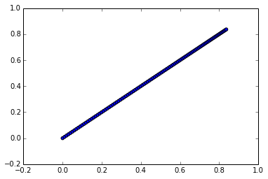

```python
data = np.arange(0,1,0.01)
y = np.sin(data)
x = np.sin(data)
fig = pl.scatter(x,y)
Pearson, Pvalue = st.pearsonr(x,y)
print 'Pearson:' + str(Pearson)
print 'P-valor:' + str(Pvalue)
```

```
Pearson:0.974262377171
P-valor:3.22851500598e-65
```

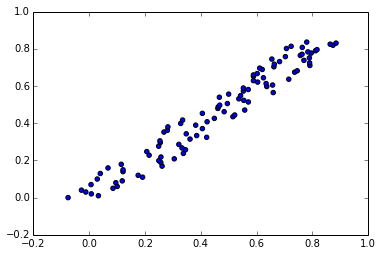

```python
y = np.sin(data)
x = np.sin(data)+np.random.uniform(-0.1,0.1,len(data))
fig = pl.scatter(x,y)
Pearson, Pvalue = st.pearsonr(x,y)
print 'Pearson:' + str(Pearson)
print 'P-valor:' + str(Pvalue)
```

```
Pearson:0.648371244826
P-valor:3.02989950926e-13
```

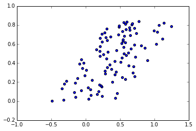

```python
y = np.sin(data)
x = np.sin(data)+np.random.uniform(-0.5,0.5,len(data))
fig = pl.scatter(x,y)
Pearson, Pvalue = st.pearsonr(x,y)
print 'Pearson:' + str(Pearson)
print 'P-valor:' + str(Pvalue)
```

```
Pearson:0.844113465885
P-valor:2.80736484788e-28
```

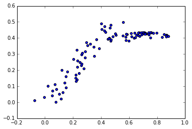

```python
y = np.sin(data)
x = np.sin(data)+np.random.uniform(-0.1,0.1,len(data))
pos = np.where(y>0.5)[0]
y[pos] = y[pos]-(pos/150.0)**2
fig = pl.scatter(x,y)
Pearson, Pvalue = st.pearsonr(x,y)
print 'Pearson:' + str(Pearson)
print 'P-valor:' + str(Pvalue)
```

```
Pearson:0.789062057836
P-valor:1.85241771585e-22
```

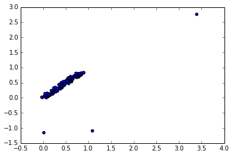

```python
y = np.sin(data)
x = np.sin(data)+np.random.uniform(-0.1,0.1,len(data))
pos = np.random.choice(100,3)
y[pos] = y[pos]+np.random.uniform(-5,5,len(pos))
x[pos] = x[pos]+np.random.uniform(-5,5,len(pos))
fig = pl.scatter(x,y)
Pearson, Pvalue = st.pearsonr(x,y)
print 'Pearson:' + str(Pearson)
print 'P-valor:' + str(Pvalue)
```

## Definición de Spearman.

Se usa como una medida de correlación no paramétrica, en la cual se tiene en cuenta el orden de la serie y no sus datos, por lo que tiende a ser más estable.

$\rho = 1- \frac{6 \sum_{i=1}{N} d_{i}^{2}}{n (n^2-1)}$

Características:

> - No asume normalidad.
> - oscila entre -1 y 1, cuando es 0 es que no hay una correlación.
> - No mide únicamente la relación lineal.
> - Mide si dos variables $x_i$ y $y_i$ crecen o decresen monoliticamente.

| IQ, $X_i$ | Hours of TV per week, $Y_i$ |
| --- | --- |
| 106 | 7 |
| 86 | 0 |
| 100 | 27 |
| 101 | 50 |
| 99 | 28 |
| 103 | 29 |
| 97 | 20 |
| 113 | 12 |
| 112 | 6 |
| 110 | 17 |

| IQ, $X_i$ | Hours of TV per week, $Y_i$ | rank $x_i$ | rank $y_i$ | $d_i$ | $d_i^2$ |
| --- | --- | --- | --- | --- | --- |
| 86 | 0 | 1 | 1 | 0 | 0 |
| 97 | 20 | 2 | 6 | −4 | 16 |
| 99 | 28 | 3 | 8 | −5 | 25 |
| 100 | 27 | 4 | 7 | −3 | 9 |
| 101 | 50 | 5 | 10 | −5 | 25 |
| 103 | 29 | 6 | 9 | −3 | 9 |
| 106 | 7 | 7 | 3 | 4 | 16 |
| 110 | 17 | 8 | 5 | 3 | 9 |
| 112 | 6 | 9 | 2 | 7 | 49 |
| 113 | 12 | 10 | 4 | 6 | 36 |

```
Spearman:0.974281428143
P-valor:3.11488667475e-65
```

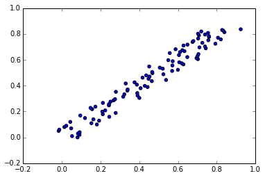

```python
y = np.sin(data)
x = np.sin(data)+np.random.uniform(-0.1,0.1,len(data))
fig = pl.scatter(x,y)
Spearman, PvalueS = st.spearmanr(x,y)
print 'Spearman:' + str(Spearman)
print 'P-valor:' + str(PvalueS)
```

```
Spearman:0.930297029703
P-valor:1.78164364453e-44
```

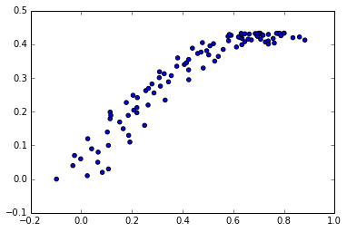

```python
y = np.sin(data)
x = np.sin(data)+np.random.uniform(-0.1,0.1,len(data))
pos = np.where(y>0.2)[0]
y[pos] = y[pos]-(pos/150.0)**2
fig = pl.scatter(x,y)
Spearman, Pvalue = st.spearmanr(x,y)
print 'Spearman:' + str(Spearman)
print 'P-valor:' + str(Pvalue)
```

## Pearson Vs Spearman.

```
Pearson:0.964133836134
Spearman:0.976225622562
```

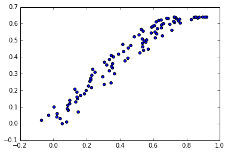

```python
y = np.sin(data)
x = np.sin(data)+np.random.uniform(-0.1,0.1,len(data))
pos = np.where(y>0.2)[0]
y[pos] = y[pos]-(pos/170.0)**3
fig = pl.scatter(x,y)
Spearman, Pvalue = st.spearmanr(x,y)
Pearson, Pvalue = st.pearsonr(x,y)
print 'Pearson:' + str(Pearson)
print 'Spearman:' + str(Spearman)
```

```
Pearson:0.187596038696
Spearman:0.887500750075
```

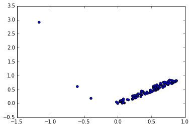

```python
y = np.sin(data)
x = np.sin(data)+np.random.uniform(-0.1,0.1,len(data))
pos = np.random.choice(100,3)
y[pos] = y[pos]+np.random.uniform(-5,5,len(pos))
x[pos] = x[pos]+np.random.uniform(-5,5,len(pos))
fig = pl.scatter(x,y)
Pearson, Pvalue = st.pearsonr(x,y)
Spearman, Pvalue = st.spearmanr(x,y)
print 'Pearson:' + str(Pearson)
print 'Spearman:' + str(Spearman)
```

## Histogramas

> - Simples $f(x)$.
> - Conjuntos $p(x,y)$.
> - Independientes: $f(x)g(y)$
> - Escaldado: $\frac{p(x,y)}{f(x)g(y)}$
- Dependen en gran medida de la selección de intervalos o **bins**
- Muestran la forma en que se distribuyen los datos.

## Simples

> - Se construyen unicamente a partir de un conjunto de datos.
> - Sensibles a la cantidad de datos y a la cantidad de intervalos
> - Pueden representar si los datos presentan o no una distribución clara.
> - No simpre son explicados por una función contínua del tipo $f(x)$

#### Histograma con muchos datos iguales

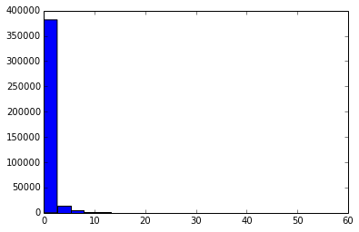

```python
a = pl.hist(Serie,bins = 20)
```

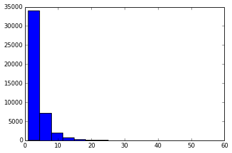

```python
a = pl.hist(Serie[Serie>1],bins = 15)
```

### Límite central en la lluvia

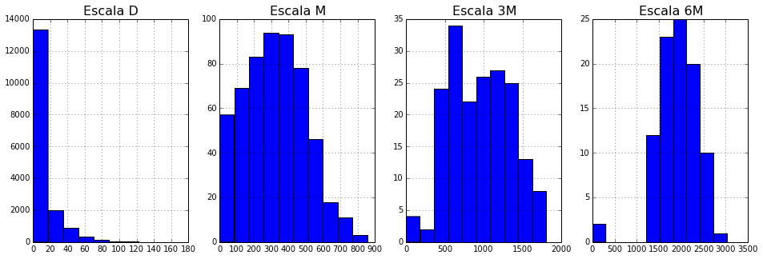

```python
fig = pl.figure(figsize=(16,5))
for cont,i in enumerate(['D','M','3M','6M']):
    ax = fig.add_subplot(1,4,cont+1)
    ax.set_title('Escala '+i,size = 16)
    Serie.resample(i,how='sum').hist(bins = 10)
```